# Deep Learning Lab Session

# First Lab Session - 3 Hours

# Artificial Neural Networks for Handwritten Digits Recognition

**Student 1:** # Lionel SOME  
**Student 2:** # Youssef AZEBA  
**Group name:** # deeplearn10

The aim of this session is to practice with Artificial Neural Networks. Answers and experiments should be made by groups of two students. Each group should fill and run appropriate notebook cells.

# Introduction

During this lab session, you will implement, train and test a Neural Network for the Handwritten Digits Recognition problem [[1]](http://yann.lecun.com/exdb/mnist/) with different settings of hyperparameters. You will use the MNIST dataset which was constructed from scanned documents available from the National Institute of Standards and Technology (NIST). Images of digits were taken from a variety of scanned documents, normalized in size and centered.

Figure 1: MNIST digits examples

This assignment includes a written part of programmes to help you understand how to build and train your neural net and then to test your code and get results.

1. NeuralNetwork.py
2. transfer_functions.py
3. utils.py

Functions defined inside the python files mentionned above can be imported using the python command "from filename import function".

You will use the following libraries:

1. [numpy](http://cs231n.github.io/python-numpy-tutorial/) : for creating arrays and using methods to manipulate arrays;
2. [matplotlib](http://matplotlib.org/) : for making plots.

Before starting the lab, please launch the cell below. After that, you may not need to do any imports during the lab.

```python
# All imports
from NeuralNetwork import NeuralNetwork
from transfer_functions import *
from utils import *
import numpy as np
import matplotlib
```

# Section 1 : Your First Neural Network

**Part 1**: Before designing and writing your code, you will first work on a neural network by hand. Consider the following neural network with two inputs $x=(x_1,x_2)$, one hidden layer and a single output unit $y$. The initial weights are set to random values. Neurons 6 and 7 represent biases. Bias values are equal to 1. You will consider a training sample whose feature vector is $x = (0.8, 0.2)$ and whose label is $y = 0.4$.

Assume that neurons have a sigmoid activation function $f(x)=\frac{1}{(1+e^{-x})}$. The loss function $L$ is a Mean Squared Error (MSE): if $o$ denotes the output of the neural network, then the loss for a given sample $(o, y)$ is $L(o, y) = \left|\left| o - y \right|\right|^2$. In the following, you will assume that if you want to backpropagate the error on a whole batch, you will backpropagate the average error on that batch. More formally, let $((x^{(1)}, y^{(1)}), ..., (x^{(N)}, y^{(N)}))$ be a batch and $o^{(k)}$ the output associated to $x^{(k)}$. Then the total error $\bar{L}$ will be as follows:

$\bar{L} = \frac{1}{N} \sum_{k=1}^{N} L(o^{(k)}, y^{(k)})$.

Figure 2: Neural network

**Question 1.1.1**: Compute the new values of weights $w_{i,j}$ after a forward pass and a backward pass, and the outputs of the neural network before and after the backward path, when the learning rate is $\lambda$=5. $w_{i,j}$ is the weight of the connexion between neuron $i$ and neuron $j$. Please detail your computations in the cell below and print your answers.

```python
lr = 5.0
x1, x2, x6, x7 = 0.8, 0.2, 1.0, 1.0
w13, w14, w23, w24, w63, w64 = 0.3, -0.5, 0.8, 0.2, 0.2, -0.4
w35, w45, w75 = -0.6, 0.4, 0.5
y = 0.4

u3=w13*x1+w23*x2+w63 #put b to -1
x3 =sigmoid(u3)

u4=x1*w14+w24*x2+w64
x4 = sigmoid(u4)

u5=w35*x3+w45*x4+w75 #put b to -1
x5 = sigmoid(u5)

print("=== FORWARD PASS 1 ===")
print("Output =", x5)

d_w35 = 2*(x5-y)*dsigmoid(u5)*x3
d_w45 = 2*(x5-y)*dsigmoid(u5)*x4
d_w75 = 2*(x5-y)*dsigmoid(u5)*x7

d_w13 = 2*(x5-y)*x1*w35*dsigmoid(u5)*dsigmoid(x3)
d_w14 = 2*(x5-y)*x1*w45*dsigmoid(u5)*dsigmoid(x4)
d_w23 = 2*(x5-y)*x2*w35*dsigmoid(u5)*dsigmoid(x3)
d_w24 = 2*(x5-y)*x2*w45*dsigmoid(u5)*dsigmoid(x4)
d_w63 = 2*(x5-y)*x6*w35*dsigmoid(u5)*dsigmoid(x3)
d_w64 = 2*(x5-y)*x6*w45*dsigmoid(u5)*dsigmoid(x4)

w13 -= lr*d_w13
w14 -= lr*d_w14
w23 -= lr*d_w23
w24 -= lr*d_w24
w63 -= lr*d_w63
w64 -= lr*d_w64
w35 -= lr*d_w35
w45 -= lr*d_w45
w75 -= lr*d_w75

print("=== BACKWARD PASS ===")
print("w13 =", w13)
print("w14 =", w14)
print("w23 =", w23)
print("w24 =", w24)
print("w63 =", w63)
print("w64 =", w64)
print("w35 =", w35)
print("w45 =", w45)
print("w75 =", w75)

u3=w13*x1+w23*x2+w63 #put b to -1
x3 =sigmoid(u3)

u4=x1*w14+w24*x2+w64
x4 = sigmoid(u4)

u5=w35*x3+w45*x4+w75 #put b to -1
x5 = sigmoid(u5)

print("=== FORWARD PASS 2 ===")
print("Output =", x5)
```

```
=== FORWARD PASS 1 ===
Output = 0.5597295991095776
=== BACKWARD PASS ===
w13 = 0.34263517938221466
w14 = -0.5307040317301952
w23 = 0.8106587948455537
w24 = 0.1923239920674512
w63 = 0.2532939742277684
w64 = -0.438380039662744
w35 = -0.8541467506279605
w45 = 0.2745727217772572
w75 = 0.10637455535192786
=== FORWARD PASS 2 ===
Output = 0.4064460781818811
```

**Part 2**: Neural Network Implementation

Please read all source files carefully and understand the data structures and all functions. You are to complete the missing code. First you should define the neural network (using the NeuralNetwork class, see in the NeuralNetwork.py file) and reinitialise weights. Then you will need to complete the feedforward() and the backpropagate() functions.

**Question 1.2.1**: Implement the feedforward() function.

```python
class NeuralNetwork(NeuralNetwork):
    def feedforward(self, inputs):

        #print("len(inputs) 0: ", len(inputs))
        # initialize arrays for activations
        self.u_hidden = np.zeros((len(inputs), self.hidden_layer_size-1))
        self.u_output = np.zeros((len(inputs), self.output_layer_size))

        # initialize arrays for outputs
        self.o_input = np.ones((len(inputs), self.input_layer_size))
        self.o_hidden = np.ones((len(inputs), self.hidden_layer_size))
        self.o_output = np.ones((len(inputs), self.output_layer_size))

        # initialize arrays for partial derivatives according to activations
        self.dE_du_hidden = np.zeros((len(inputs), self.hidden_layer_size-1))
        self.dE_du_output = np.zeros((len(inputs), self.output_layer_size))



        #output of the input layer which corresponds to the inputs (bias neuron = 1.0)

        self.o_input[:,:-1]=np.array(inputs)
        self.o_input[:,-1:]=1
        #print("len(inputs) 1: ", len(inputs))
        #activations of the hidden layer
        self.u_hidden=np.dot(self.o_input, self.W_input_to_hidden)
        #ouput of the hidden layer
        self.o_hidden[:,:-1]=self.transfer_f(self.u_hidden) #.reshape((1, len(self.transfer_f(self.u_hidden))))

        # set bias neuron in hidden layer to 1.0
        self.o_hidden[:, -1:]=1

        #print("sigmoid(self.u_hidden[i])", np.array(sigmoid(self.u_hidden[i])).shape)
        #print("self.o_hidden[i] shape", np.array(self.o_hidden[i,:-1]).shape)
        #activations of the output layer
        self.u_output=np.dot(self.o_hidden, self.W_hidden_to_output)
        #output of the output layer
        self.o_output=self.transfer_f(self.u_output)
        #print("self.o_output[0] shape", self.o_output[0].shape)
```

**Question 1.2.2**: Test your implementation: create the Neural Network defined in Part 1 and see if the feedforward() function you implemented gives the same results as the ones you found by hand.

```python
w13, w14, w23, w24, w63, w64 = 0.3, -0.5, 0.8, 0.2, 0.2, -0.4
w35, w45, w75 = -0.6, 0.4, 0.5

# First define your neural network
model = NeuralNetwork(input_layer_size=2, hidden_layer_size=2, output_layer_size=1, transfer_f=sigmoid, transfer_df=dsigmoid)

# Then initialize the weights according to Figure 2
W_input_to_hidden = [[w13, w14], [w23, w24], [w63, w64]]
W_hidden_to_output = [[w35], [w45], [w75]]
model.weights_init(W_input_to_hidden, W_hidden_to_output)

# Feed test values
test = [[[0.8, 0.2]]]
model.feedforward(test)


# Print the output
print("Output =", model.o_output[0,0])
```

```
Output = 0.5597295991095776
```

**Question 1.2.3**: Implement the backpropagate() function.

```python
class NeuralNetwork(NeuralNetwork):
    def backpropagate(self, targets, learning_rate=5.0):

            #error
            ##########################
            error=(self.o_output-np.array(targets))
            #derivative of the error with respect to the activation for the output layer
            self.dE_du_output=self.transfer_df(self.u_output)*error*2/len(targets)
            #derivative of the error with respect to the activation for the hidden layer

            self.dE_du_hidden=self.transfer_df(self.u_hidden)*np.dot( self.dE_du_output, self.W_hidden_to_output[:-1,:].T )
            # weight changes for the output layer
            self.W_hidden_to_output-=learning_rate*np.dot(np.asmatrix(self.o_hidden).T , np.asmatrix(self.dE_du_output))
            # weight changes for the hidden layer
            self.W_input_to_hidden-=learning_rate*np.dot(np.asmatrix(self.o_input).T,np.asmatrix(self.dE_du_hidden) )
```

**Question 1.2.4**: Test your implementation: create the Neural Network defined in Part 1 and see if the backpropagate() function you implemented gives the same weight updates as the ones you found by hand. Do another forward pass and see if the new output is the same as the one you obtained in Question 1.1.1.

```python
w13, w14, w23, w24, w63, w64 = 0.3, -0.5, 0.8, 0.2, 0.2, -0.4
w35, w45, w75 = -0.6, 0.4, 0.5

# First define your neural network
model = NeuralNetwork(input_layer_size=2, hidden_layer_size=2, output_layer_size=1, transfer_f=sigmoid, transfer_df=dsigmoid)

# Then initialize the weights according to Figure 2
W_input_to_hidden = np.array([[w13, w14], [w23, w24], [w63, w64]])
W_hidden_to_output = np.array([[w35], [w45], [w75]])
model.weights_init(W_input_to_hidden, W_hidden_to_output)

# Feed test values
test = [[[0.8, 0.2]]]
model.feedforward(test)

# Backpropagate
targets = [[0.4]]
model.backpropagate(targets)

# Print weights
print("W_input_to_hidden =", model.W_input_to_hidden)
print("W_hidden_to_output =", model.W_hidden_to_output)

# Feed test values again
model.feedforward(test)

# Print the output
print("Output =", model.o_output[0,0])
```

```
W_input_to_hidden = [[ 0.34322654 -0.52734731]
 [ 0.81080664  0.19316317]
 [ 0.25403318 -0.43418414]]
W_hidden_to_output = [[-0.85414675]
 [ 0.27457272]
 [ 0.10637456]]
Output = 0.40648823589210104
```

Checked your implementations and found that everything was fine? Congratulations! You can move to the next section.

# Section 2: Handwritten Digits Recognition

The MNIST dataset consists of handwritten digit images. It is split into a training set containing 60,000 samples and a test set containing 10,000 samples. In this Lab Session, the official training set of 60,000 images is divided into an actual training set of 50,000 samples a validation set of 10,000 samples. All digit images have been size-normalized and centered in a fixed size image of 28 x 28 pixels. Images are stored in byte form: you will use the NumPy python library to convert data files into NumPy arrays that you will use to train your Neural Networks.

You will first work with a small subset of MNIST (1000 samples), then on a very small subset of MNIST (10 samples), and eventually run a model on the whole one.

The MNIST dataset is available in the Data folder. To get the training, testing and validation data, run the load_data() function.

```python
# Just run that cell ;-)
training_data, validation_data, test_data = load_data()
small_training_data = (training_data[0][:1000], training_data[1][:1000])
small_validation_data = (validation_data[0][:200], validation_data[1][:200])
indices = [1, 3, 5, 7, 2, 0, 13, 15, 17, 4]
vsmall_training_data = ([training_data[0][i] for i in indices], [training_data[1][i] for i in indices])
```

```
Loading MNIST data .....
Done.
```

```python
# And you can run that cell if you want to see what the MNIST dataset looks like
ROW = 2
COLUMN = 5
for i in range(ROW * COLUMN):
    # train[i][0] is i-th image data with size 28x28
    image = np.array(training_data[0][i]).reshape(28, 28)
    plt.subplot(ROW, COLUMN, i+1)
    plt.imshow(image, cmap='gray')  # cmap='gray' is for black and white picture.
plt.axis('off')  # do not show axis value
plt.tight_layout()   # automatic padding between subplots
plt.show()
```

[output not shown]

**Part 1**: Build a bigger Neural Network

The input layer of the neural network that you will build contains neurons encoding the values of the input pixels. The training data for the network will consist of many 28 by 28 pixel images of scanned handwritten digits. Thus, the input layer contains 784=28×28 units. The second layer of the network is a hidden layer. We set the number of neurons in the hidden layer to 30. The output layer contains 10 neurons.

**Question 2.1.1**: Create the network described above using the NeuralNetwork class.

```python
lr_list=[0.1, 1, 10]
def training(n_hidden,training_data,validation_data, lr_list):
    """function to define a neural network with a hidden layer size set
       to the parameter n_hidden. the function trains our model using the
       parameters: training_data, validation data and the learning rates list """
    # Definition of our neural network
    mnist_model = NeuralNetwork(input_layer_size=784, hidden_layer_size=n_hidden, output_layer_size=10, transfer_f=sigmoid, transfer_df=dsigmoid)
    #Learning rates list
    LearningRates=lr_list

    for i,lr in enumerate(LearningRates):
        print(i+1,")  Training with a learning rate of ", lr,":")
        mnist_model.weights_init(wi=None,wo=None)
        mnist_model.train(training_data, validation_data, iterations=300, learning_rate=lr, verbose=False)
        acc=mnist_model.predict(test_data)/len(test_data[0])*100
        print("The accuracy on test data is: ", acc," % \n\n")
```

**Question 2.1.2**: Train your Neural Network on the small subset of MNIST (300 iterations) and print the new accuracy on test data. You will use small_validation_data for validation. Try different learning rates (0.1, 1.0, 10.0). You should use the train() function of the NeuralNetwork class to train your network, and the weights_init() function to reinitialize weights between tests. Print the accuracy of each model on test data using the predict() function.

```
1 )  Training with a learning rate of  0.1 :
Training time: 18.39459490776062
```

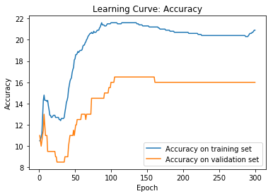

```
The accuracy on test data is:  19.6  %


2 )  Training with a learning rate of  1 :
Training time: 16.569618940353394
```

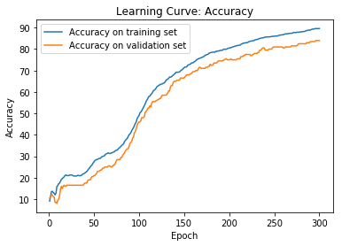

```
The accuracy on test data is:  83.45  %


3 )  Training with a learning rate of  10 :
Training time: 16.389058589935303
```

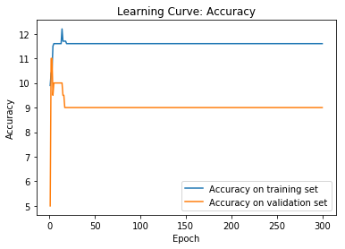

```
The accuracy on test data is:  10.39  %
```

```python
# Train NN and print accuracy on test data
# Learning rate 0.1, 1., 10.
#hidden layer size = 30
training(30,small_training_data,small_validation_data, lr_list)
```

**Question 2.1.3**: Do the same with 15 and 75 hidden neurons.

```
1 )  Training with a learning rate of  0.1 :
Training time: 16.0496883392334
```

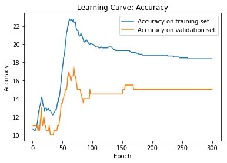

```
The accuracy on test data is:  17.82  %


2 )  Training with a learning rate of  1 :
Training time: 15.689924716949463
```

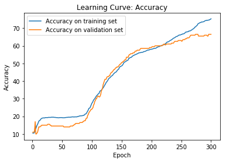

```
The accuracy on test data is:  70.83  %


3 )  Training with a learning rate of  10 :
Training time: 15.46358585357666
```

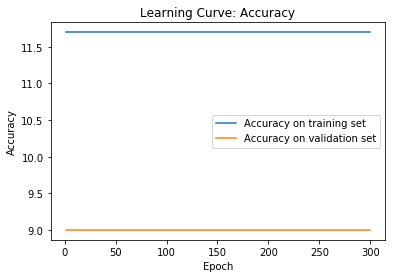

```
The accuracy on test data is:  10.280000000000001  %
```

```python
# Train NN and print accuracy on test data
# Learning rate 0.1, 1., 10.
#hidden layer size = 15
training(15,small_training_data,small_validation_data, lr_list)
```

```
1 )  Training with a learning rate of  0.1 :
Training time: 19.495001554489136
```

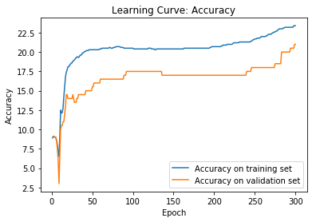

```
The accuracy on test data is:  22.54  %


2 )  Training with a learning rate of  1 :
Training time: 19.342738151550293
```

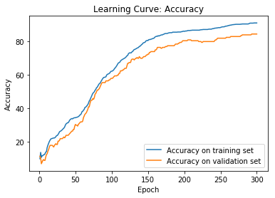

```
The accuracy on test data is:  84.97  %


3 )  Training with a learning rate of  10 :
Training time: 19.954740047454834
```

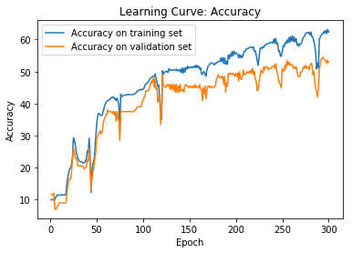

```
The accuracy on test data is:  54.33  %
```

```python
# Train NN and print accuracy on test data
# Learning rate 0.1, 1., 10.
#hidden layer size = 75
training(75,small_training_data,small_validation_data, lr_list)
```

**Question 2.1.3**: Repeat Questions 2.1.2 and 2.1.3 on the very small datasets. You will use small_validation_data for validation.

```
1 )  Training with a learning rate of  0.1 :
Training time: 1.4719510078430176
```

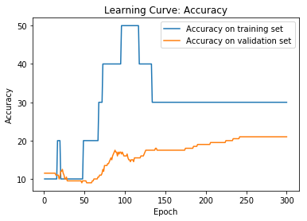

```
The accuracy on test data is:  19.36  %


2 )  Training with a learning rate of  1 :
Training time: 1.444751501083374
```

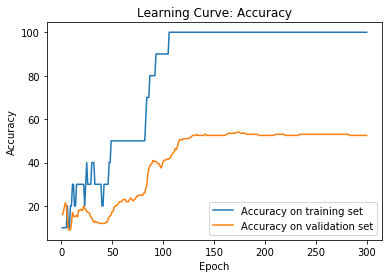

```
The accuracy on test data is:  50.83  %


3 )  Training with a learning rate of  10 :
Training time: 1.4508123397827148
```

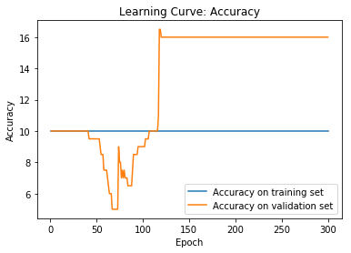

```
The accuracy on test data is:  10.47  %
```

```python
# Train NN and print accuracy on test data
# Learning rate 0.1, 1., 10.
#hidden layer size = 15
training(15,vsmall_training_data,small_validation_data, lr_list)
```

```
1 )  Training with a learning rate of  0.1 :
Training time: 1.5694775581359863
```

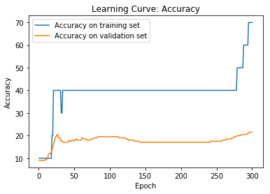

```
The accuracy on test data is:  22.24  %


2 )  Training with a learning rate of  1 :
Training time: 1.66941499710083
```

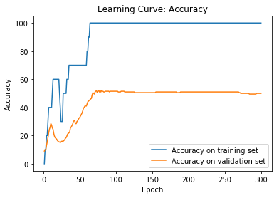

```
The accuracy on test data is:  50.849999999999994  %


3 )  Training with a learning rate of  10 :
Training time: 1.498659372329712
```

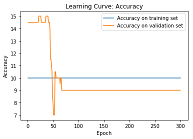

```
The accuracy on test data is:  9.32  %
```

```python
# Train NN and print accuracy on test data
# Learning rate 0.1, 1., 10.
#hidden layer size = 30
training(30,vsmall_training_data,small_validation_data, lr_list)
```

```
1 )  Training with a learning rate of  0.1 :
Training time: 1.8415429592132568
```

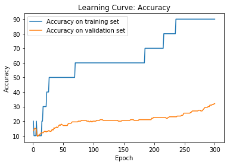

```
The accuracy on test data is:  33.98  %


2 )  Training with a learning rate of  1 :
Training time: 1.8436353206634521
```

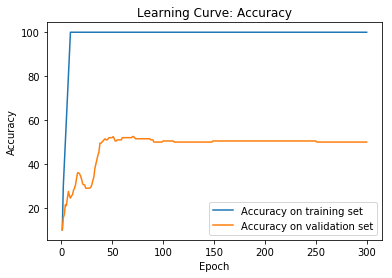

```
The accuracy on test data is:  50.339999999999996  %


3 )  Training with a learning rate of  10 :
Training time: 1.9301245212554932
```

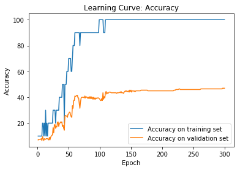

```
The accuracy on test data is:  45.73  %
```

```python
# Train NN and print accuracy on test data
# Learning rate 0.1, 1., 10.
#hidden layer size = 75
training(75,vsmall_training_data,small_validation_data, lr_list)
```

**Question 2.1.5**: Explain the results you obtained at Questions 2.1.2, 2.1.3 and 2.1.4.

```
Text(0.5,0,'Number of hidden neurons')
```

[figure not shown]

```python
#number of hidden neurons
n=[15,30,75]
#accuracy list for small training data
accuracy_small_lr01=[17.82,18.4,22.54]
accuracy_small_lr1=[70.83,83.45,19.34]
accuracy_small_lr10=[10.28,10.39,19.95]
#accuracy list for very small training data
accuracy_vsmall_lr01=[19.36,22.24,33.98]
accuracy_vsmall_lr1=[50.83,50.85,50.34]
accuracy_vsmall_lr10=[10.47,9.32,45.73]

fig=plt.figure(figsize=(20,5))
#A plot to show the accuracy on small training data with respect to the number of hidden neurons
plt.subplot(121)
plt.plot(n, accuracy_small_lr01, color='b', label='learning rate=0.1')
plt.plot(n, accuracy_small_lr1, color='r', label='learning rate=1.')
plt.plot(n, accuracy_small_lr10, color='g', label='learning rate=10.')
plt.legend()
plt.ylabel('Accuracy %')
plt.xlabel('Number of hidden neurons')
plt.title("Accuracy on small training data")
plt.grid()
#A plot to show the accuracy on very small training data with respect to the number of hidden neurons
plt.subplot(122)
plt.title("Accuracy on very small training data")
plt.plot(n, accuracy_vsmall_lr01, color='b', label='learning rate=0.1')
plt.plot(n, accuracy_vsmall_lr1, color='r', label='learning rate=1.')
plt.plot(n, accuracy_vsmall_lr10, color='g', label='learning rate=10.')
plt.grid()
plt.legend()
plt.ylabel('Accuracy %')
plt.xlabel('Number of hidden neurons')
```

**Question 2.1.6**: Among all the numbers of hidden neurons and learning rates you tried in previous questions, which ones would you expect to achieve best performances on the whole dataset? Justify your answer.

**Question 2.1.7**: Train a model with the number of hidden neurons and the learning rate you chose in Question 2.1.6 and print its accuracy on the test set. You will use validation_data for validation. Training can be long on the whole dataset (~40 minutes): we suggest that you work on the optional part while waiting for the training to finish.

```
1 )  Training with a learning rate of  1.0 :
Training time: 898.0215921401978  s
```

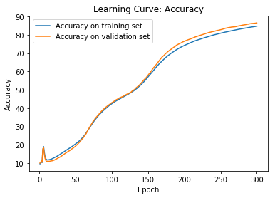

```
The accuracy on test data is:  85.86  %
```

```python
# Train NN and print accuracy on test data
# Learning rate 1.
#hidden layer size = 30
training(30,training_data,validation_data, [1.])
```

```
1 )  Training with a learning rate of  1.0 :
Training time: 1181.797924041748  s
```

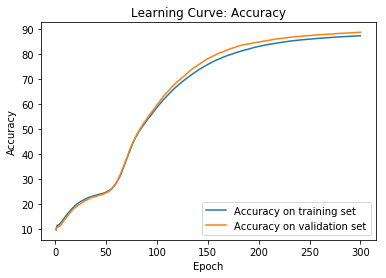

```
The accuracy on test data is:  88.44999999999999  %
```

```python
# Train NN and print accuracy on test data
# Learning rate 1.
#hidden kayer size = 75
training(75,training_data,validation_data, [1.])
```

**Inference**  
We decided to see the accuracy with 75 hidden neurons other things being equal to verify that we don't have any overfitting anymore since the training data have now a bigger size (50000 samples).  
We can see that we have also a very good accuracy of 88.45% which is nearby the 85.86% we got with 30 hidden neurons. A neural network of 75 hidden is also a good choice even if it takes more time (1181.797924041748s compared to 898.0215921401978s for the one with 30 hidden neurons) but with better results. So, depending on how important the accuracy is (if we are working in a critical domain for example it may be important to have the highest accuracy) we can chose between 30 and 75 hidden neurons.

```
Training with a learning rate of 0.1
Training time: 1056.5677559375763
```

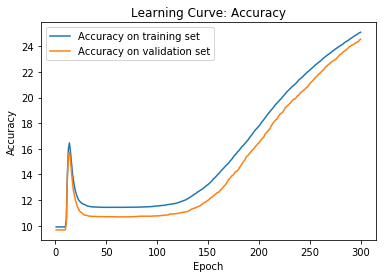

```
The accuracy on test data is:  26.11
```

```python
mnist_model = NeuralNetwork(input_layer_size=784, hidden_layer_size=75, output_layer_size=10, transfer_f=sigmoid, transfer_df=dsigmoid)
mnist_model.weights_init(wi=None,wo=None)
print("Training with a learning rate of 0.1")
mnist_model.train(training_data, validation_data, iterations=300, learning_rate=0.1, verbose=False)
acc=mnist_model.predict(test_data)/len(test_data[0])*100
print("The accuracy on test data is: ", acc)
```

```
1000 iterations training  with a learning rate of 1.
Training time: 3788.4736535549164  s
```

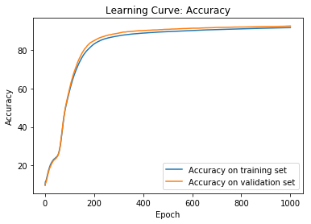

```
The accuracy on test data is:  92.21000000000001
```

```python
#increasing the number of iterations to see the convergence
mnist_model = NeuralNetwork(input_layer_size=784, hidden_layer_size=75, output_layer_size=10, transfer_f=sigmoid, transfer_df=dsigmoid)
mnist_model.weights_init(wi=None,wo=None)
print("1000 iterations training  with a learning rate of 1.")
mnist_model.train(training_data, validation_data, iterations=1000, learning_rate=1., verbose=False)
acc=mnist_model.predict(test_data)/len(test_data[0])*100
print("The accuracy on test data is: ", acc)
```

**Part 2 (optional)**: Another loss function

In classification problems, we usually replace the sigmoids in the output layer by a "softmax" function and the MSE loss by a "cross-entropy" loss. More formally, let $u = (u_1, ..., u_n)$ be the vector representing the activation of the output layer of a Neural Network. The output of that neural network is $o = (o_1, ..., o_n) = \textrm{softmax}(u)$, and

$\textrm{softmax}(u) = (\frac{e^{u_1}}{\sum_{k=1}^n e^{u_k}}, ..., \frac{e^{u_n}}{\sum_{k=1}^n e^{u_k}})$.

If $t = (t_1, ..., t_n)$ is a vector of non-negative targets such that $\sum_{k=1}^n t_k = 1$ (which is the case in classification problems, where one target is equal to 1 and all others are equal to 0), then the cross-entropy loss is defined as follows:

$L_{xe}(o, t) = - \sum_{k=1}^n t_k\log(o_k)$.

**Question 2.2.1**: Let $L_{xe}$ be the cross-entropy loss function and $u_i$, $i \in \lbrace 1, ..., n \rbrace$, be the activations of the output neurons. Let us assume that the transfer function of the output neurons is the softmax function. Targets are $t_1, ..., t_n$. Derive a formula for $\frac{\partial L_{xe}}{\partial u_i}$ (details of your calculations are not required).

Answer: $\frac{\partial L_{xe}}{\partial u_i} = o_i-t_i=\textrm{softmax}(u_i)-t_i$

**Question 2.2.2**: Implement a new feedforward() function and a new backpropagate() function adapted to the cross-entropy loss instead of the MSE loss.

```python
class NeuralNetwork(NeuralNetwork):
    def feedforward_xe(self, inputs):

        # initialize arrays for activations
        self.u_hidden = np.zeros((len(inputs), self.hidden_layer_size-1))
        self.u_output = np.zeros((len(inputs), self.output_layer_size))

        # initialize arrays for outputs
        self.o_input = np.ones((len(inputs), self.input_layer_size))
        self.o_hidden = np.ones((len(inputs), self.hidden_layer_size))
        self.o_output = np.ones((len(inputs), self.output_layer_size))

        # initialize arrays for partial derivatives according to activations
        self.dE_du_hidden = np.zeros((len(inputs), self.hidden_layer_size-1))
        self.dE_du_output = np.zeros((len(inputs), self.output_layer_size))



        #output of the input layer which corresponds to the inputs (bias neuron = 1.0)
        self.o_input[:,:-1]=np.array(inputs)
        self.o_input[:,-1:]=1
        #activations of the hidden layer
        self.u_hidden=np.dot(self.o_input, self.W_input_to_hidden)
        #ouput of the hidden layer
        self.o_hidden[:,:-1]=self.transfer_f(self.u_hidden) #.reshape((1, len(self.transfer_f(self.u_hidden))))
        # set bias neuron in hidden layer to 1.0
        self.o_hidden[:, -1:]=1
        #activations of the output layer
        self.u_output=np.dot(self.o_hidden, self.W_hidden_to_output)

        #all the lines above are the same with the first feedforward function
        #output of the output layer using the softmax function
        self.o_output=softmax(self.u_output)



    def backpropagate_xe(self, targets, learning_rate=5.0):

            #derivative of the error with respect to the activation for the output layer
            self.dE_du_output=(self.o_output-targets)/len(targets)
            #derivative of the error with respect to the activation for the hidden layer

            self.dE_du_hidden=self.transfer_df(self.u_hidden)*np.dot( self.dE_du_output, self.W_hidden_to_output[:-1,:].T )
            #self.dE_du_hidden=self.transfer_df(self.u_hidden)*np.dot( self.dE_du_output, self.W_hidden_to_output[:-1,:].T )
            # weight changes for the output layer
            self.W_hidden_to_output-=learning_rate*np.dot(self.o_hidden.T , self.dE_du_output)
            # weight changes for the hidden layer
            self.W_input_to_hidden-=learning_rate*np.dot(self.o_input.T,self.dE_du_hidden )
```

**Question 2.2.3**: Create a new Neural Network with the same architecture as in Question 2.1.1 and train it using the softmax cross-entropy loss.

```
Training  with a learning rate of 1.
Training time: 911.3711094856262
```

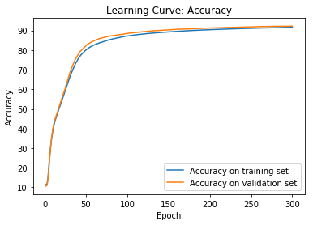

```python
# Definition of our neural network
mnist_model_xe = NeuralNetwork(input_layer_size=784, hidden_layer_size=30, output_layer_size=10, transfer_f=sigmoid, transfer_df=dsigmoid)

# Train NN and print accuracy on validation data
mnist_model_xe.weights_init(wi=None,wo=None)
print("Training  with a learning rate of 1.")
mnist_model_xe.train_xe(training_data, validation_data, iterations=300, learning_rate=1., verbose=False)
```

```python
# Print accuracy on test data
acc=mnist_model_xe.predict(test_data)/len(test_data[0])*100
print("The accuracy on test data is: ", acc)
```

```
The accuracy on test data is:  91.97
```

**Question 2.2.4**: Compare your results with the MSE loss and with the cross-entropy loss.

**Answer:**  
All things being equal, when using the cross-entropy loss with the softmax function, we obtain an accuracy of 91.97% which is much higher than the 85.86% we got with the MSE loss. It is even close (92.21%) to what we obtain with a neural network with 75 hidden neurons and *1000* iterations.  
The softmax function reacts to low stimulation of our neural net with rather uniform distribution and to high stimulation (ie. large numbers) with probabilities close to 0 and 1. It tries to minimize the cross-entropy between the predictions and the truth, that's why it gives better results than the MSE loss.

**THE END!**